# Information, uncertainty and hypothesis testing for random regressions on environmental covariates

Daniel J. Tolhurst

$\newcommand{\what}[1]{\mathord{\rlap{\kern-0.25em\hat{\phantom{#1}}}#1}}$ $\newcommand{\wtilde}[1]{\mathord{\rlap{\kern-0.26em\tilde{\phantom{#1}}}#1}}$

# 1 Preliminaries

Consider a linear random regression for $g_{ij}$, the effect of genotype $i$ in environment $j$, which is given by:

$$g_{ij}=u_{0i}+s_j u_{1i}$$

where $u_{0i}$ is the genotype intercept, $u_{1i}$ is the genotype slope and $s_j$ is a centred environmental covariate. Because $s_j$ is centred at zero, $u_{0i}$ represents the main effect of genotype $i$, given by its mean performance across environments, and $u_{1i}$ represents its sensitivity to the covariate.

It is assumed that:
$$\begin{bmatrix}
u_{0i}\\
u_{1i}
\end{bmatrix}
\sim
\mathrm{N}
\left(
\begin{bmatrix}
0\\
0
\end{bmatrix},
\begin{bmatrix}
\sigma_0^2 & \sigma_{01}\\
\sigma_{01} & \sigma_1^2
\end{bmatrix}
\right).$$

The genetic variance of environment $j$ is therefore given by:

$$\sigma_{g_j}^2
=
\sigma_0^2
+
2s_j\sigma_{01}
+
s_j^2\sigma_1^2$$

with genetic covariance between environments $j$ and $k$ given by:

$$\sigma_{g_{jk}}
=
\sigma_0^2
+
(s_j+s_k)\sigma_{01}
+
s_js_k\sigma_1^2.$$

These expressions define the common genetic structure considered below. The distinction between single- and two-stage analyses concerns how information from the phenotypic data is carried into estimation and prediction of $u_{0i}$ and $u_{1i}$.

## 1.1 Single-stage analysis

The single-stage linear mixed model for $y_{ijk}$, the phenotype for observation $k$ of genotype $i$ in environment $j$, can be written as:

$$y_{ijk}
=
\tau_j
+
u_{0i}
+
s_j u_{1i}
+
e_{ijk}$$

where $\tau_j$ is the fixed effect of environment $j$, $u_{0i}$ is the genotype intercept, $u_{1i}$ is the genotype slope, $s_j$ is the centred environmental covariate and $e_{ijk}$ is the residual effect for observation $k$ of genotype $i$ in environment $j$.

It is assumed that:
$$\begin{bmatrix}
u_{0i}\\
u_{1i}\\
e_{ijk}
\end{bmatrix}
\sim
\mathrm{N}
\left(
\begin{bmatrix}
0\\
0\\
0
\end{bmatrix},
\begin{bmatrix}
\sigma_0^2 & \sigma_{01} & 0\\
\sigma_{01} & \sigma_1^2 & 0\\
0 & 0 & \sigma_e^2
\end{bmatrix}
\right)$$

The model therefore estimates the genotype intercepts and slopes directly from the phenotypic observations while accounting for differences in mean performance among environments through $\tau_j$. The information available for prediction of $u_{0i}$ and $u_{1i}$ depends on the number and precision of observations for genotype $i$ and on the positions of the environments in which it is observed along the covariate $s_j$. This will be formalised further below.

## 1.2 Two-stage analysis

In a two-stage analysis, genotype performance is first estimated separately within each environment. The first-stage linear mixed model for $y_{ijk}$ can be written as:

$$y_{ijk}
=
g_{ij}
+
e_{ijk}$$

where $g_{ij}$ is the fixed genotype effect of genotype $i$ in environment $j$ and $e_{ijk}$ is the residual for observation $k$.

It is assumed that $e_{ijk} \sim \mathrm{N} (0, \sigma_{e_j}^2)$, where $\sigma_{e_j}^2$ is the residual variances for environment $j$.

The first-stage analysis provides an estimate of genotype performance, $\what{g}_{ij}$, along with its error variance $v_{ij} = \mathrm{Var} \left( \what g_{ij}-g_{ij} \right)$.

The second-stage random regression is then fitted to the estimated genotype effects:

$$\what{g}_{ij}
=
u_{0i}
+
s_j u_{1i}
+
\varepsilon_{ij}$$

where $u_{0i}$ is the genotype intercept, $u_{1i}$ is the genotype slope and $\varepsilon_{ij}$ represents uncertainty carried forward from the first-stage analysis.

Following Smith et al. (2001), a diagonal weighting scheme is applied where the weights for environment $j$ are given by:
$$\mathbf w_j
=
\operatorname{diag}
\left(
\mathbf V_j^{-1}
\right)$$

where $\mathbf V_j$ is the variance-covariance matrix of the adjusted genotype means from the first-stage analysis. Thus, the individual weight $w_{ij}$ is the corresponding diagonal element of $\mathbf V_j^{-1}$ rather than simply the reciprocal of the marginal variance of $\what g_{ij}$ given by $v^{-1}_{ij}$.

The information available for prediction of $u_{0i}$ and $u_{1i}$ therefore depends on both the precision of the first-stage estimate $\what g_{ij}$ and the position of environment $j$ along the covariate $s_j$. In practice, first-stage estimates may be correlated, in which case the full variance-covariance matrix of the estimates should be carried forward to the second-stage analysis rather than using only its diagonal. A single-stage analysis is preferable because this information is retained directly within the mixed model.

# 2 Leverage and uncertainty along the environmental covariate

## 2.1 Information contributed by the environments

The information provided by environment $j$ depends on both the precision with which genotype $i$ is measured in that environment and its position along the environmental covariate. Let $\omega_{ij}$ denote the effective precision of the observations for genotype $i$ in environment $j$. The contribution of environment $j$ to the information for the genotype intercept and slope can then be written as:

$$\boldsymbol \Omega_{ij}
=
\omega_{ij}
\begin{bmatrix}
1 & s_j\\
s_j & s_j^2
\end{bmatrix}.$$

Summing across the environments in which genotype $i$ is observed gives:

$$\sum_j \boldsymbol \Omega_{ij}
=
\begin{bmatrix}
\sum_j \omega_{ij} & \sum_j \omega_{ij}s_j \\
\sum_j \omega_{ij}s_j & \sum_j \omega_{ij}s_j^2
\end{bmatrix}
=
\begin{bmatrix}
A_i & B_i \\
B_i & C_i
\end{bmatrix}$$
The quantity $A_i = \sum_j \omega_{ij}$ describes the total information available for genotype $i$, while $B_i = \sum_j \omega_{ij}s_j$ describes the balance of this information around the centre of the environmental covariate and $C_i = \sum_j \omega_{ij}s_j^2$ describes the information available at increasing distance from the centre.

The information-weighted mean position of genotype $i$ along the environmental covariate is:

$$\bar{s}_i
=
\frac{B_i}{A_i}
=
\frac{\sum_j\omega_{ij}s_j}
{\sum_j\omega_{ij}}.$$

After accounting for estimation of the intercept, the information available for estimation of the slope is:

$$I_{1i}
=
C_i-\frac{B_i^2}{A_i}
=
\sum_j
\omega_{ij}
(s_j-\bar{s}_i)^2.$$

This expression separates the two components determining information for the genotype slope. Environments with greater precision contribute more information through $\omega_{ij}$, while environments further from the information-weighted centre contribute greater leverage through $(s_j-\bar{s}_i)^2$. Consequently, precise observations spanning a wide range of the environmental covariate provide substantially more information for estimating $u_{1i}$ than equally precise observations concentrated within a narrow range of $s_j$. This dependence of random-regression precision on the number and distribution of observations along the covariate is well established (Martin et al. 2011).

A useful environment-specific measure of leverage for the slope is therefore:

$$L_{ij}
=
\omega_{ij}
(s_j-\bar{s}_i)^2.$$

The relative contribution of environment $j$ to the slope information for genotype $i$ can be expressed as:

$$L_{ij}^{*}
=
\frac{L_{ij}}
{\sum_jL_{ij}}.$$

These quantities provide a direct diagnostic of where information for genotype sensitivity is concentrated along the environmental covariate. Plotting $\omega_{ij}$ and $L_{ij}^{*}$ against $s_j$ can therefore identify regions of the environmental gradient that are poorly represented or weakly measured.

Lastly, the contribution of environment $j$ to slope information across all genotypes observed in that environment can be summarised as:

$$L_j
=
\sum_{i}
L_{ij}.$$

The relative contribution of environment $j$ to the total slope information in the dataset is then:

$$L_j^*
=
\frac{L_j}
{\sum_j L_j}.$$

For example, $L_j^*=0.20$ indicates that environment $j$ contributes 20% of the total information available for estimation of genotype slopes across the dataset.

### 2.1.1 Single-stage analysis

For the simple single-stage model described above, each independent phenotypic observation has residual precision $\sigma_e^{-2}$. If genotype $i$ has $r_{ij}$ observations in environment $j$, let $q_{ij}=\frac{r_{ij}}{\sigma_e^2}$ and its contribution to precision is given by:

$$\omega_{ij}
=
q_{ij} - \frac{q_{ij}^2}{\sum_i q_{ij}}$$
where the second term arises due to absorption of the fixed environment means. Under a balanced design with $r$ replicates of $v_j$ genotypes, $\omega_{ij} = \frac{r}{\sigma_e^2}(1 - \frac{1}{v_j})$ for all $i$.

More generally, let $\boldsymbol \Omega$ denote the coefficient matrix for all random effects after absorbing the fixed effects, such that:

$$\boldsymbol \Omega = \mathbf Z^\top
\mathbf S
\mathbf Z$$
where $\mathbf Z$ is the $n\times 2v$ random effect design matrix, with non-zero entries given by 1 for the genotype intercepts and $s_j$ for the genotype slopes, and $\mathbf S$ is the $n\times n$ residual projection matrix given by:
$$\mathbf S = \mathbf R^{-1}
- \mathbf R^{-1}\mathbf X
\left(
\mathbf X^\top\mathbf R^{-1}\mathbf X
\right)^{-1}
\mathbf X^\top\mathbf R^{-1}$$
where $\mathbf X$ is the fixed effect design matrix and $\mathbf R$ is the $n\times n$ residual variance-covariance matrix.

The matrix $\boldsymbol \Omega$ therefore contains the phenotypic information available for prediction of the random effects after accounting for the fixed effects, including both the information associated with each individual random-regression coefficient and the cross-products between coefficients induced by the experimental design. The information contributed by genotype $i$ in environment $j$ is given by the $2\times2$ matrix: $\boldsymbol \Omega_{ij} = \mathbf Z_{ij\cdot}^\top \mathbf S\mathbf Z_{ij\cdot}$, where $\mathbf Z_{ij\cdot}$ is a $n\times 2$ matrix given by the two columns of the full design matrix corresponding to the intercept of genotype $i$ and its position in environment $j$, such that $\mathbf Z_{ij\cdot}$ contains $r_{ij}$ non-zero rows. When the fixed effects only contain the environment mean parameters, $\boldsymbol \Omega_{ij}$ reduces to the form in the previous section, with $\omega_{ij}$ as defined above. The form of $\omega_{ij}$ here can then be substituted into the environment-level summaries in the previous section.

Under balanced designs this provides a simple interpretation of the environmental information. In more general single-stage analyses, the effective precision is determined by the mixed-model equations after accounting for fixed effects, imbalance, replication and any additional residual or experimental covariance structure. The information quantities above can therefore be obtained directly from the appropriate block of the mixed-model coefficient matrix rather than being reconstructed from trial-level summaries.

Importantly, measures such as environment-specific heritability or reliability may be useful diagnostics of variation in genetic signal along $s_j$, but are not themselves measures of the information contributed to estimation of the random regression. For example, environment-specific heritability can be expressed as:
$$h_j^2
=
\frac{\sigma_{g_j}^2\bar{G}_j}
{\sigma_{g_j}^2\bar{G}_j+\sigma_e^2/\bar{r}_j}$$
where $\bar{G}_j$ is the mean diagonal element of the relationship matrix, obtaining by averaging over genotypes observed in environment $j$, given by $\bar{G}_j = \frac{1}{v_j} \sum_{i} {G_{ii}}$, and $\bar{r}_j$ is the effective replication for that environment, given by $\bar{r}_j= \left( \frac{1}{v_j} \sum_{i} \frac{1}{r_{ij}} \right)^{-1}$, where $v_j$ is the number of genotypes observed in environment $j$.

The reliability of the predicted effect for genotype~$i$ in environment~$j$, denoted by $\wtilde g_{ij} = \wtilde u_{0i} + s_j\wtilde u_{1i}$, can be written as:

$$r_{ij}^2
=
1-
\frac{\operatorname{PEV}_{ij}}
{\sigma_{g_j}^2G_{ii}}.$$

with prediction error variance:

$$\operatorname{PEV}_{ij}
=
\operatorname{Var}
\left[
\left(\wtilde u_{0i}-u_{0i}\right)
+
s_j
\left(\wtilde u_{1i}-u_{1i}\right)
\right].$$

These quantities describe the strength and predictability of genetic signal within an environment, whereas $\omega_{ij}$ describes the information contributed by the phenotypic observations to estimation of the random regression. Consequently, environments with similar heritability or mean reliability can contribute substantially different information because of differences in replication, experimental design, connectivity and position along the environmental covariate.

### 2.1.2 Two-stage analysis

For the two-stage analysis, the corresponding precision is provided by the weights carried forward from the first-stage analysis. Under the diagonal weighting scheme of Smith et al. (2001):

$$\omega_{ij}
=
w_{ij}$$

where $w_{ij}$ is the corresponding diagonal element of $\mathbf V_j^{-1}$.

The information quantities $A_i$, $B_i$ and $C_i$, and consequently $I_{1i}$ and $L_{ij}^{*}$, can therefore be calculated directly from the first-stage weights and environmental covariates. If the full variance-covariance matrix of the first-stage estimates is carried forward, the same principles apply but the information is obtained from the complete weighted cross-product rather than from independent scalar weights.

The remainder of the document focuses on the single-stage analysis.

## 2.2 Reliability of the intercepts and slopes

The information contributed by the phenotypic data must be combined with the genetic variance-covariance structure when predicting the genotype intercepts and slopes. Let:

$$\boldsymbol\Sigma
=
\begin{bmatrix}
\sigma_0^2 & \sigma_{01}\\
\sigma_{01} & \sigma_1^2
\end{bmatrix}
\qquad
\text{and}
\qquad
\boldsymbol{\Omega}_{ii}
=
\begin{bmatrix}
\sum_j \omega_{ij} & \sum_j \omega_{ij}s_j \\
\sum_j \omega_{ij}s_j & \sum_j \omega_{ij}s_j^2
\end{bmatrix}.$$
Let $\mathbf G$ denote the relationship matrix between genotypes and $\boldsymbol{\Omega}$ denote the $2v\times2v$ coefficient matrix for all genotypes, obtained after absorbing the fixed effects. The diagonal block $\boldsymbol{\Omega}_{ii}$ is defined above, while the off-diagonal blocks $\boldsymbol{\Omega}_{ii'}$ contain the cross-genotype information arising from estimation of the fixed effects and any residual covariance between observations, obtained from $\boldsymbol \Omega = \mathbf Z^\top \mathbf S \mathbf Z$.

Conditional on the estimated variance parameters, the prediction error variance-covariance matrix between the intercept and slope for genotype $i$ is obtained from the corresponding $2\times 2$ block of:
$$\mathbf{PEV}
=
\left(
\boldsymbol \Omega \, + \, \mathbf G^{-1}\hskip -2pt\otimes
\boldsymbol\Sigma^{-1}
\right)^{-1}.$$
The prediction error variance provides the conventional model-based measure of uncertainty for a predicted random effect (Henderson 1984; Gorjanc, Bijma, and Hickey 2015). The reliabilities of the predicted intercept and slope for genotype $i$ are therefore:

$$r_{0i}^2
=
1-
\frac{\operatorname{PEV}_{0i}}
{\sigma_0^2G_{ii}}
\qquad
\text{and}
\qquad
r_{1i}^2
=
1-
\frac{\operatorname{PEV}_{1i}}
{\sigma_1^2G_{ii}}$$

where $\operatorname{PEV}_{0i}$ and $\operatorname{PEV}_{1i}$ are the corresponding diagonal elements of $\mathbf{PEV}$. In practice, the elements corresponding to genotype $i$ can be obtained by considering covariate values of $-1,0$ and $1$ as:
$$\text{PEV}_{0i} = \text{PEV}(\wtilde{g}_{ij}|s_j=0)
\qquad
\text{and}
\qquad
\text{PEV}_{1i} = \frac{1}{2}\left[\text{PEV}(\wtilde{g}_{ij}|s_j=1) +
\text{PEV}(\wtilde{g}_{ij}|s_j=-1) -2\text{PEV}_{0i}\right]$$
such that $\text{PEV}_{01i}=\frac{1}{4}\big[\text{PEV}(\wtilde{g}_{ij}|s_j=1)-\text{PEV}(\wtilde{g}_{ij}|s_j=-1)\big]$ and $\mathbf{PEV}_{ii}$ is constructed accordingly.

These reliabilities depend not only on the total amount of phenotypic information but also on how that information is distributed along the environmental covariate. In particular, the off-diagonal information term $B_i=\sum_j \omega_{ij}s_j$ determines the extent to which the phenotypic data distinguish the genotype intercept from its slope. If the observations for genotype $i$ are information-weighted around the centre of the covariate:

$$B_i
=
\sum_j\omega_{ij}s_j
=
0$$

then the intercept and slope are orthogonal in the information contributed by the data. If $B_i\neq0$, information for the intercept and slope is partially confounded, even when the genetic covariance $\sigma_{01}$ is zero. In other words, the intercept is estimated most cleanly when a genotype is observed with similar information on both sides of the centre of the environmental covariate. If its observations are concentrated towards one end of the covariate, changes in intercept and slope can produce similar fitted values over the observed range, making the two effects harder to distinguish and reducing the precision of both predictions.

The data alone also provide a natural effective error variance for estimation of the genotype slope. From the conditional slope information, $I_{1i} = C_i-\frac{B_i^2}{A_i}$, and hence the effective error variance is:
$$\sigma_{e_{1i}}^2
=
I_{1i}^{-1}
=
\left(
C_i-\frac{B_i^2}{A_i}
\right)^{-1}
=
\left[
\sum_j
\omega_{ij}
(s_j-\bar{s}_i)^2
\right]^{-1}.$$

This quantity has a simple interpretation as the error variance with which the slope of genotype $i$ can be estimated from its phenotypic records. It decreases as observations become more precise and as they span a wider range of the environmental covariate.

An analogous effective error variance for the genotype intercept, after accounting for estimation of the slope, is:

$$\sigma_{e_{0i}}^2
=
\left(
A_i-\frac{B_i^2}{C_i}
\right)^{-1}
= \frac{1}{\sum_j
\omega_{ij}} + \frac{\bar{s}_i^2}{\sum_j
\omega_{ij}
(s_j-\bar{s}_i)^2}$$
noting that the denominator of the second term is eqivalent to the information on the slopes.

The effective error variances above describe the independent information contained in the phenotypic data and are distinct from the prediction error variances, which additionally depend on the genetic variance-covariance matrix $\boldsymbol \Sigma$. When the intercepts and slopes are genetically correlated, $\sigma_{01}$ also contributes to their prediction and reliability through information sharing between the two random coefficients.

The effective error variances can be used to obtain the population-level reliability of the intercepts, which is given by:

$$r_{0}^2
=
\frac{\sigma_0^2\bar{G}}
{\sigma_0^2\bar{G}+\sigma_{e_{0}}^2}$$
where $\sigma_{e_{0}}^2=\frac{1}{v}\sum_{i=1}^v\sigma_{e_{0i}}^2$. Under a balanced design with $r$ replicates of $v$ genotypes in each of $p$ environments and centred covariates, the effective error variance reduces to $\sigma_{e_{0}}^2=\sigma_{e}^2/pr$ and the resulting heritability is given by:
$$h_{0}^2
=
\frac{\sigma_0^2\bar{G}}
{\sigma_0^2\bar{G}+\sigma_e^2/pr}$$
noting that the slope variance does not enter the expression in such cases because the slope contributions average to zero across environments, i.e. $B_i = \sum_{j=1}^p \omega_{ij}s_j=0$ for all $i$. In other words, the intercept can be estimated independently of the slope even when the intercepts and slopes are genetically correlated, provided that their information is orthogonal.

A similar population-level reliability can be obtained for the slopes, given by:

$$r_{1}^2
=
\frac{\sigma_1^2\bar{G}}
{\sigma_1^2\bar{G}+\sigma_{e_{1}}^2}$$

where $\sigma_{e_{1}}^2=\frac{1}{v}\sum_{i=1}^v\sigma_{e_{1i}}^2$. Under a balanced design with $r$ replicates of $v$ genotypes in each of $p$ environments and centred covariates, the effective error variance reduces to $\sigma_{e_{1}}^2 = \frac{\sigma_e^2} {r\sum_{j=1}^{p}s_j^2}.$ and the resulting heritability is given by:
$$h_{1}^2
=
\frac{\sigma_1^2\bar{G}}
{\sigma_1^2\bar{G}
+
\sigma_e^2/
\left(
r\sum_{j=1}^{p}s_j^2
\right)}$$

which has the same form as a traditional heritability measure, but the effective replication for the slope depends not only on the number of phenotypic observations but also on the spread of the environments along the covariate. Thus, increasing replication increases the reliability of the slopes, while increasing the range of $s_j$ also increases reliability by providing greater leverage for distinguishing differences in environmental sensitivity among genotypes.

The following section considers a transformation that decorrelates the genotype intercepts and slopes. This separates the variance in sensitivity associated with the genotype intercept from the independent variance in sensitivity and permits the reliability of the independent slope component to be expressed directly in the familiar form of a genetic variance relative to genetic plus effective error variance.

# 3 Decorrelating the intercepts and slopes

The covariance between the genotype intercepts and slopes implies that part of the genetic variation in environmental sensitivity is associated with variation in mean genotype performance. To separate this component from independent variation in sensitivity, the genotype slope can be adjusted for its linear association with the genotype intercept. Let:

$$\beta
=
\frac{\sigma_{01}}
{\sigma_0^2}
\qquad
\text{and}
\qquad
u_{1i}^*
=
u_{1i}
-
\beta u_{0i}$$
where $\beta$ is the slope of the regression of the genotype slopes onto the genotype intercepts and $u_{1i}^*$ is the adjusted slope for genotype $i$, such that $\operatorname{cov} \left( u_{0i}, \, u_{1i}^* \right) = 0$. The variance of the adjusted slopes is then given by:
$$\sigma_{1}^{*2}
=
\sigma_1^2
-
\frac{\sigma_{01}^2}{\sigma_0^2}
= \sigma_1^2
-
\beta^2{\sigma_0^2}.$$

The original genotype slope and its variance can therefore be decomposed as:
$$u_{1i}
=
\beta u_{0i}
+
u_{1i}^*
\qquad
\text{and}
\qquad
\sigma_1^2
=
\frac{\sigma_{01}^2}{\sigma_0^2}
+
\sigma_{1}^{*2}.$$

where ${\sigma_{01}^2}/{\sigma_0^2}$ represents variation in genotype sensitivity along the environmental covariate associated with the genotype intercept, while $\sigma_{1}^{*2}$ represents variation in sensitivity that is independent of the genotype intercept.

Substituting this decomposition into the random regression gives:

$$\begin{align}
g_{ij}
&=
u_{0i}
+
s_j
(
\beta u_{0i}
+
u_{1i}^*
)\\
&=
(1+\beta s_j)
u_{0i}
+
s_j u_{1i}^*.
\end{align}$$

It then follows that:
$$\begin{bmatrix}
u_{0i}\\
u^*_{1i}
\end{bmatrix}
\sim
\mathrm{N}
\left(
\begin{bmatrix}
0\\
0
\end{bmatrix},
\begin{bmatrix}
\sigma_0^2 & 0\\
0 & \sigma_1^{*2}
\end{bmatrix}
\right).$$
and let
$$\boldsymbol\Sigma^*
=
\begin{bmatrix}
\sigma_0^2 & 0\\
0 & \sigma_{1}^{*2}
\end{bmatrix}.$$
Although the transformed genetic coefficients are uncorrelated, the information contributed by the phenotypic data need not be orthogonal. For genotype $i$, the coefficient matrix of the transformed effects, after absorbing the fixed effects, is given by:

$$\boldsymbol{\Omega}_{ii}^*
=
\begin{bmatrix}
\sum_j
\omega_{ij}(1+\beta s_j)^2
&
\sum_j
\omega_{ij}s_j(1+\beta s_j)
\\
\sum_j
\omega_{ij}s_j(1+\beta s_j)
&
\sum_j
\omega_{ij}s_j^2
\end{bmatrix}
=
\begin{bmatrix}
A_i^* & B_i^*\\
B_i^* & C_i^*
\end{bmatrix}$$
where:
$$A_i^*
=
A_i+2\beta B_i+\beta^2C_i,
\qquad
B_i^*
=
B_i+\beta C_i
\qquad
\text{and}
\qquad
C_i^*
=
C_i.$$

Thus, decorrelation of the genetic coefficients does not necessarily decorrelate their phenotypic information. In particular, $B_i^*$ describes the extent to which information for the genotype intercept and adjusted slope remains confounded after the genetic transformation.

Let $\boldsymbol{\Omega}^*$ denote the $2v\times 2v$ coefficient matrix for all genotypes, obtained after absorbing the fixed effects, with $2\times2$ diagonal block $\boldsymbol{\Omega}_{ii}$ given above. Conditional on the estimated variance parameters, the prediction error variance-covariance matrix for the transformed effects is:

$$\mathbf{PEV}^*
=
\left[
\boldsymbol{\Omega}^* + \, \mathbf{G}^{-1} \hskip -2pt \otimes
\boldsymbol\Sigma^{*-1}
\right]^{-1}.$$
Consider the rotation matrix and its inverse matrix given by:
$$\mathbf B = \begin{bmatrix}
1 & 0 \\
-\beta & 1
\end{bmatrix}
\quad
\text{and}
\quad
\mathbf B^{-1} = \begin{bmatrix}
1 & 0 \\
\beta & 1
\end{bmatrix},
\qquad
\text{such that}
\quad
\begin{bmatrix}
u_{0i}\\
u^*_{1i}
\end{bmatrix} =
\begin{bmatrix}
1 & 0 \\
-\beta & 1
\end{bmatrix}
\begin{bmatrix}
u_{0i}\\
u_{1i}
\end{bmatrix}
\quad
\text{and}
\quad
\begin{bmatrix}
u_{0i}\\
u_{1i}
\end{bmatrix} =
\begin{bmatrix}
1 & 0 \\
\beta & 1
\end{bmatrix}
\begin{bmatrix}
u_{0i}\\
u^*_{1i}
\end{bmatrix}.$$
It then follows that $\boldsymbol\Sigma^* = \mathbf B\boldsymbol\Sigma\mathbf B^\top$ and $\boldsymbol\Omega^* = (\mathbf{I}_v\otimes\mathbf B^{-1})^\top \boldsymbol\Omega\,(\mathbf{I}_v\otimes\mathbf B^{-1})$.

The genotype-level reliability of the adjusted slope is therefore:

$$r_{1i}^{*2}
=
1-
\frac{\operatorname{PEV}_{1i}^*}
{\sigma_{1}^{*2}G_{ii}}$$

where $\operatorname{PEV}_{1i}^*$ is the diagonal element of $\mathbf{PEV}^*$ corresponding to $u_{1i}^*$. In practice, the elements corresponding to genotype $i$ can be obtained by applying the rotation matrix as:
$$\mathbf{PEV}^*_{ii} = (\mathbf{I}_v\otimes\mathbf
B)\,\mathbf{PEV}_{ii}(\mathbf{I}_v\otimes\mathbf B^\top).$$

Because $u_{1i}^*$ is genetically independent of the intercept, its reliability can also be expressed using the effective information available for its prediction. Accounting for uncertainty in the intercept, the effective error variance for the adjusted slope is:

$$\sigma_{e_{1i}}^{*2}
= \left(
I_{1i}^*
\right)^{-1} =
\left(C_i^*
-
\frac{{B_i^*}^2}
{A_i^*+\left(\sigma_0^2G_{ii}\right)^{-1}}\right)^{-1} =
\left[
\sum_j \omega_{ij}s_j^2
-
\frac{
\left[
\sum_j \omega_{ij}s_j(1+\beta s_j)
\right]^2
}{
\sum_j \omega_{ij}(1+\beta s_j)^2
+
\left(\sigma_0^2G_{ii}\right)^{-1}
}
\right]^{-1}.$$

The population-level reliability of the adjusted slopes can therefore be written as:

$$r_{1}^{*2}
=
\frac{\sigma_{1}^{*2}\bar{G}}
{\sigma_{1}^{*2}\bar{G}
+
\sigma_{e_{1}}^{*2}}$$
where $\sigma_{e_{1}}^{*2}=\frac{1}{v}\sum_{i=1}^v\sigma_{e_{1i}}^{*2}$. Under a balanced design with $r$ replicates of $v$ genotypes in each of $p$ environments and centred covariates, $B_i=0$ but $B_i^=\beta C_i$. Consequently, the zero genetic correlation between the intercept and slope does not generally imply orthogonality of their phenotypic information, and only reduces to the simpler form when $\beta=0$.

This highlights an important distinction from the unadjusted slopes. For the original random regression, centring the environmental covariate is sufficient to orthogonalise the intercept and slope information under a balanced design because $B_i=0$. After decorrelation, however, the intercept enters the model through $(1+\beta s_j)$ rather than as a constant coefficient of one. The transformation therefore couples estimation of the intercept and adjusted slope through $B_i^*=\beta C_i$, even when the original information is perfectly balanced. As a result, balanced data no longer reduce the effective error variance of the adjusted slope to the simpler form obtained for the unadjusted slope unless $\beta=0$. In other words, the genetic decorrelation that makes $u_{1i}^*$ independent of the intercept also induces a dependence between their estimation from the phenotypic data.

# 4 Hypothesis testing

## 4.1 Approach 1: Sequential log-likelihood ratio test

Conventionally, evidence for genetic variation in genotype sensitivity to an environmental covariate can be assessed by comparing an intercept-only model with a full random regression. This comparison simultaneously introduces the slope variance, $\sigma_1^2$, and the covariance between the intercept and slope, $\sigma_{01}$, and therefore tests:

$$H_0:
\sigma_1^2=0
\quad\text{and}\quad
\sigma_{01}=0.$$

This joint test has been widely used for random-slope and reaction-norm models (Pol 2012; Erbe et al. 2022). However, it does not distinguish between sensitivity associated with the genotype intercept and independent genetic variation in sensitivity.

The decorrelated parameterisation allows these components to be tested sequentially. Consider three models:

$$M_0:
\qquad
g_{ij}=u_{0i}
\qquad
\text{where}
\quad
\Sigma = \sigma_0^2
\quad
\text{(intercept only, 1 parameter)}$$

$$M_R:
\qquad
g_{ij}
=
(1+\beta s_j)u_{0i}
\qquad
\text{where}
\quad
\boldsymbol\Sigma
=
\sigma_0^2\begin{bmatrix}
1 & \beta\\
\beta & \beta^2
\end{bmatrix}
\quad
\text{(rank-1 variance structure, 2 parameters)}$$
$$M_F:
\qquad
g_{ij}
=
(1+\beta s_j)u_{0i}
+
s_j u_{1i}^*
\qquad
\text{where}
\quad
\boldsymbol\Sigma
=
\begin{bmatrix}
\sigma_0^2 & 0\\
0 & \sigma_1^{*2}
\end{bmatrix}
\quad
\text{(rank-2 variance structure, 3 parameters)}$$
Note that all variance parameters re-estimated under each model

The first likelihood-ratio test statistic is:
$$LR_{\beta}
=
2
\left(
\ell_R-\ell_0
\right)$$

which tests $H_0:\beta=0$, that is whether genotype sensitivity is associated with variation in the genotype intercept. The test statistic is distributed as $LR_{\beta}\sim\chi_1^2$.

The second likelihood-ratio test statistic is:
$$LR_{1^*}
=
2
\left(
\ell_F-\ell_R
\right)$$
which tests $H_0: \sigma_{1}^{*2}=0.$, that is whether additional genetic variation in genotype sensitivity remains after accounting for the sensitivity associated with the genotype intercept. The test statistic is distributed as $LR_{1^*} \sim \frac{1}{2}\chi_0^2 + \frac{1}{2}\chi_1^2$, where $\chi_0^2$ denotes a point mass at zero (Self and Liang 1987; Stram and Lee 1994)

The conventional joint comparison between the intercept-only and full models can therefore be written as:

$$LR_{\mathrm{total}}
=
2
\left(
\ell_F-\ell_0
\right)
=
LR_{\beta}+LR_{1^*}$$
with test statistic distributed as $LR_{\mathrm{total}} \sim \frac{1}{2}\chi_1^2 + \frac{1}{2}\chi_2^2$ (Pol 2012; Erbe et al. 2022). The sequential decomposition therefore partitions the evidence for genotype sensitivity into that associated with the genotype intercept and that arising from independent variation in sensitivity.

Lastly, a model can be fitted which assumes independent intercepts and slopes:

$$M_R^*:
\qquad
g_{ij}
=
u_{0i}
+
s_j u_{1i}
\qquad
\text{where}
\quad
\boldsymbol\Sigma
=
\begin{bmatrix}
\sigma_0^2 & 0\\
0 & \sigma_1^{2}
\end{bmatrix}
\quad
\text{(rank-2 variance structure, 2 parameters)}.$$
The likelihood-ratio test statistic is:

$$LR_{01}
=
2
\left(
\ell_F-\ell_R^*
\right)$$
which tests $H_0: \sigma_{01}=0$, that is whether the observed sensitivity is genetically associated with differences in genotype mean performance. The test statistic is distributed as $LR_{01}\sim\chi_1^2$.

## 4.2 Approach 2: Conditional log-likelihood ratio test

An alternative is to construct a likelihood directly from the information remaining for the adjusted slopes after accounting for uncertainty in the genotype intercepts. This provides a likelihood analogue of the effective slope information introduced above.

Reorder the transformed random effects such that the intercepts and adjusted slopes are grouped separately, and partition the coefficient matrix as:

$$\boldsymbol\Omega^*
=
\begin{bmatrix}
\boldsymbol\Omega_{00}^*
&
\boldsymbol\Omega_{01}^*
\\
\boldsymbol\Omega_{10}^*
&
\boldsymbol\Omega_{11}^*
\end{bmatrix}.$$

After accounting for the prior information on the genotype intercepts, the conditional information available for the adjusted slopes is given by the Schur complement:

$$\boldsymbol\Omega_{1|0}^*
=
\boldsymbol\Omega_{11}^*
-
\boldsymbol\Omega_{10}^*
\big(
\boldsymbol\Omega_{00}^*
+
\mathbf G^{-1}/\sigma_0^2
\big)^{-1}
\boldsymbol\Omega_{01}^*.$$

This is the joint analogue of the genotype-specific quantity $I_{1i}^*$ derived above. Let:

$$\mathbf E_{1|0}^*
=
\left(
\boldsymbol\Omega_{1|0}^*
\right)^{-1}$$

denote the corresponding effective error variance-covariance matrix and let $\widetilde{\mathbf u}_{1|0}^*$ denote the conditional working values for the adjusted slopes after accounting for the intercepts. These may be represented as:

$$\widetilde{\mathbf u}_{1|0}^*
=
\mathbf u_1^*
+
\mathbf e_{1|0}^*$$

where:

$$\mathbf u_1^*
\sim
\mathrm N
\left(
\mathbf 0,
\sigma_1^{*2}\mathbf G
\right)
\qquad
\text{and}
\qquad
\mathbf e_{1|0}^*
\sim
\mathrm N
\left(
\mathbf 0,
\mathbf E_{1|0}^*
\right).$$

The marginal covariance of the conditional working values is therefore:

$$\mathbf V_{1|0}^*
=
\sigma_1^{*2}\mathbf G
+
\mathbf E_{1|0}^*.$$

Ignoring constants, the corresponding conditional log-likelihood can be written as:

$$\ell_c
\left(
\sigma_1^{*2}
\right)
=
-\frac{1}{2}
\left[
\log
\left|
\mathbf V_{1|0}^*
\right|
+
\widetilde{\mathbf u}_{1|0}^{*\top}
\mathbf V_{1|0}^{*-1}
\widetilde{\mathbf u}_{1|0}^*
\right].$$

A conditional likelihood-ratio statistic can then be defined as:

$$LR_{1^*}^{c}
=
2
\left[
\ell_c
\left(
\widehat{\sigma}_{1}^{*2}
\right)
-
\ell_c(0)
\right]$$
where:
$$\ell_c(0)
=
-\frac{1}{2}
\left[
\log
\left|
\mathbf E_{1|0}^*
\right|
+
\widetilde{\mathbf u}_{1|0}^{*\top}
\left(
\mathbf E_{1|0}^*
\right)^{-1}
\widetilde{\mathbf u}_{1|0}^*
\right].$$

This approach tests the same biological hypothesis, $H_0:\sigma_1^{*2}=0$, but does so using the information for the adjusted slopes remaining after the intercept component has been absorbed. The test statistic is distributed as $LR_{1^*}^{c}\sim\frac{1}{2}\chi_0^2+\frac{1}{2}\chi_1^2$. Unlike the sequential likelihood-ratio test, its equivalence to the full-data likelihood-ratio test is not assumed here and can be evaluated through simulation, particularly under imbalance, strong intercept-slope coupling and different levels of genetic relatedness.

# 5 Application to simulated data

The methods above are demonstrated using a single-stage analysis of a simulated multi-environment trial dataset containing $v=200$ genotypes evaluated across $p=50$ environments. The environmental covariate, $s_j$, spans a continuous range and is centred to have mean zero. Genotype intercept and slope variances are each set to 1, with a positive intercept-slope correlation of 0.6. An additional environment-specific genetic variance is simulated independently for each environment, with mean 2, to represent genetic variation not captured by the random regression. Residual variances are also heterogeneous across environments, with mean 4.

A genomic relationship matrix is generated from simulated marker data and used for all genetic effects. The dataset initially contains two replicates per genotype within each environment, producing 20,000 phenotypes. Imbalance is introduced by removing 50% of the genotype by environment combinations. Of the 5,000 observed combinations, 50% retain two replicates and 50% are reduced to a single replicate. The final dataset therefore contains 2,500 genotype by environment combinations with two replicates and 2,500 with one replicate, giving 7,500 phenotypic observations in total. In summary, 50% of all possible genotype by environment combinations have phenotypic data, with a partial replication of 0.5 among the observed combinations.

The above setting creates variation among genotypes in both the amount and distribution of information available across the environmental covariate, while variation among environments in genetic and residual variance produces heterogeneous reliability.

## 5.1 Simulating phenotypic data

```r
# Packages
library(asreml)
```

```r
library(ggplot2)
library(Matrix)
library(FieldSimR)

set.seed(1234)


# -------------------------------------------------------------------------
# Simulation settings
# -------------------------------------------------------------------------

nenvs <- 50
ngenos <- 200
nreps <- 2
nmarkers <- 1000
prop_missing <- 0.50
prep <- 0.50

geno_names <- paste0("G", seq_len(ngenos))
env_names <- paste0("E", seq_len(nenvs))

# Environmental covariate
s <- sort(rnorm(nenvs))
s <- s - mean(s)
names(s) <- env_names
cov_df <- data.frame(env = factor(env_names, levels = env_names),
                     s = s)
# Environment means
tau <- 5 + s

# Random-regression genetic variance parameters
var_0 <- 1
var_1 <- 1
cor_01 <- 0.6
cov_01 <- cor_01 * sqrt(var_0 * var_1)
Sigma <- matrix(c(var_0, cov_01,
                  cov_01, var_1), nrow = 2)

# Mean environment-specific variances
var_g <- 2
var_e <- 4

# Genomic relationship matrix
p <- runif(nmarkers, 0.1, 0.5)
M <- sapply(p, function(x) rbinom(ngenos, 2, x))
M <- scale(M, scale = FALSE)
G <- tcrossprod(M) / (2 * sum(p * (1 - p)))
G <- G + diag(1e-6, ngenos)
G <- G / mean(diag(G))
dimnames(G) <- list(geno_names, geno_names)


# -------------------------------------------------------------------------
# Simulate genetic effects
# -------------------------------------------------------------------------

# Genotype intercepts and slopes
LG <- t(chol(G))
LS <- t(chol(Sigma))
U <- LG %*% matrix(rnorm(ngenos * 2), ngenos, 2) %*% t(LS)
colnames(U) <- c("u0", "u1")
rownames(U) <- geno_names
gv_df <- data.frame(geno = factor(geno_names, levels = geno_names),
                    u0 = U[, "u0"],
                    u1 = U[, "u1"])

# Check realised random-regression covariance
cov(gv_df[, c("u0", "u1")])
```

```
##           u0        u1
## u0 0.9075473 0.5495658
## u1 0.5495658 1.0835317
```

```r
# Heterogeneous environment-specific genetic and residual variances
var_gj <- diag(skew_diag_mat(n = nenvs, mean.var = var_g))
var_ej <- diag(skew_diag_mat(n = nenvs, mean.var = var_e))
names(var_gj) <- names(var_ej) <- env_names

# Environment-specific genetic effects and errors
delta <- sapply(seq_len(nenvs), function(j) sqrt(var_gj[j]) * LG %*% rnorm(ngenos))
error <- sapply(seq_len(nenvs), function(j) sqrt(var_ej[j]) * rnorm(ngenos*nreps))
rownames(delta) <- geno_names
colnames(delta) <- colnames(error) <- env_names


# -------------------------------------------------------------------------
# Construct trial and impose imbalance
# -------------------------------------------------------------------------

pheno_df <- expand.grid(env = env_names,
                        geno = geno_names,
                        rep = seq_len(nreps),
                        KEEP.OUT.ATTRS = FALSE)
pheno_df$env <- factor(pheno_df$env, levels = env_names)
pheno_df$geno <- factor(pheno_df$geno, levels = geno_names)
pheno_df$rep <- factor(pheno_df$rep)
pheno_df <- pheno_df[order(pheno_df$env, pheno_df$rep, pheno_df$geno),]
pheno_df$e.mean <- tau[trimws(pheno_df$env)]
pheno_df$intercept <- gv_df[trimws(pheno_df$geno),"u0"]
pheno_df$slope <- gv_df[trimws(pheno_df$geno),"u1"]
pheno_df$gv.reg <- pheno_df$intercept + pheno_df$slope*s[trimws(pheno_df$env)]
pheno_df$gv.dev <- c(rbind(delta, delta))
pheno_df$gv.tot <- pheno_df$gv.reg + pheno_df$gv.dev
pheno_df$e <- c(error)
pheno_df$y <- pheno_df$e.mean + pheno_df$gv.tot + pheno_df$e
head(pheno_df)
```

```
##     env geno rep   e.mean  intercept      slope     gv.reg      gv.dev
## 1    E1   G1   1 3.107355 -0.2339958 -0.8334717  1.3434700 -0.69854657
## 51   E1   G2   1 3.107355 -1.0535525 -1.0697050  0.9710190  0.56333972
## 101  E1   G3   1 3.107355 -1.7707504 -0.5533888 -0.7233821 -0.20654777
## 151  E1   G4   1 3.107355  1.4019928 -0.3314623  2.0293332  1.24393592
## 201  E1   G5   1 3.107355  0.3367547  0.3337738 -0.2949604 -0.04759842
## 251  E1   G6   1 3.107355  0.2348841  1.9212579 -3.4013744 -0.89683400
##         gv.tot          e         y
## 1    0.6449235 -1.3627552 2.3895236
## 51   1.5343588  0.5731040 5.2148180
## 101 -0.9299299  0.9724937 3.1499191
## 151  3.2732691  2.8171782 9.1978026
## 201 -0.3425588 -0.4837104 2.2810860
## 251 -4.2982084  1.4521238 0.2612707
```

```r
# Remove 50% of genotype x environment combinations
ge_combo <- interaction(pheno_df$env, pheno_df$geno, drop = TRUE)
missing <- sample(levels(ge_combo), length(levels(ge_combo)) * prop_missing)
keep <- setdiff(levels(ge_combo), missing)
one_rep <- sample(keep, length(keep) * prep)
pheno_df$y[ge_combo %in% missing] <- NA
pheno_df$y[ge_combo %in% one_rep & pheno_df$rep == 2] <- NA
rownames(pheno_df) <- NULL


# -------------------------------------------------------------------------
# Checks
# -------------------------------------------------------------------------

# Number of genotypes per environment and vice versa
summary(with(pheno_df[!is.na(pheno_df$y),], tapply(geno, env, function(x) length(unique(x)))))
```

```
##    Min. 1st Qu.  Median    Mean 3rd Qu.    Max.
##    88.0    94.0   100.5   100.0   105.0   119.0
```

```r
summary(with(pheno_df[!is.na(pheno_df$y),], tapply(env, geno, function(x) length(unique(x)))))
```

```
##    Min. 1st Qu.  Median    Mean 3rd Qu.    Max.
##   15.00   22.75   25.00   25.00   28.00   34.00
```

```r
# Replication of genotype x environment combinations
table(with(pheno_df[!is.na(pheno_df$y),], table(geno, env)))
```

```
##
##    0    1    2
## 5000 2500 2500
```

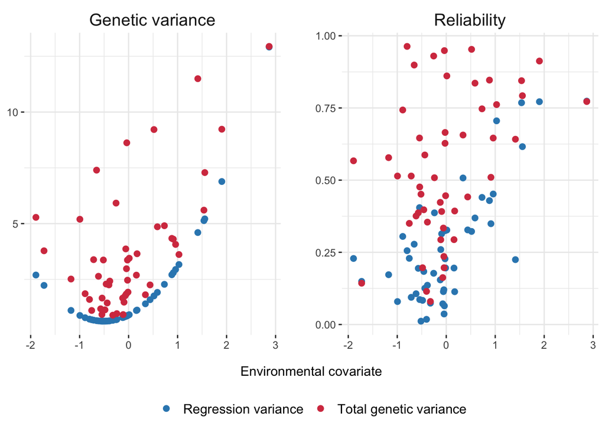

The simulated data exhibit substantial heterogeneity in both genetic variance and reliability across the environmental covariate, arising from the combined effects of the random regression, environment-specific genetic deviations, heterogeneous residual variance and trial imbalance. The random-regression component represents the structured genetic signal associated with the environmental covariate, whereas the total genetic value additionally includes environment-specific genetic variation. These quantities describe the information structure present in the simulated dataset before model fitting. In the following sections, linear mixed models are fitted to examine how this heterogeneity in information across environments affects estimation and prediction of the random-regression intercept and slope components.

## 5.2 Sequential likelihood-ratio tests

The four models described previously were fitted using ASReml-R. The same fixed environment effects and residual structure were fitted in each model, with all variance parameters re-estimated. Likelihood-ratio tests are used to separate different sources of genotype sensitivity along the environmental covariate. The intercept-only model provides the baseline with no genetic variation in sensitivity, while the rank-1 model tests whether sensitivity is associated with the genotype intercept. The full random-regression model then tests whether additional, independent genetic variation in sensitivity remains after accounting for this association. For comparison, the conventional joint test evaluates the overall evidence for random regression, while the independent intercept–slope model tests specifically whether the intercept and slope are genetically correlated.

```r
# -------------------------------------------------------------------------
# Sequential likelihood-ratio tests
# -------------------------------------------------------------------------

pheno_df2 <- pheno_df[!is.na(pheno_df$y),] # remove missing data

# M0: genotype intercept only
M_0 <- asreml(y ~ env,
              random = ~ vm(geno, G) +
                         diag(env):vm(geno, G),
              residual = ~ dsum(~ units | env),
              data = pheno_df2)
```

```
## ASReml Version 4.2 15/09/2026 10:02:58
##           LogLik        Sigma2     DF     wall
##  1     -10564.77           1.0   7450   10:02:59  (  1 restrained)
##  2     -10268.63           1.0   7450   10:03:00  (  2 restrained)
##  3     -10116.53           1.0   7450   10:03:00  (  1 restrained)
##  4     -9970.515           1.0   7450   10:03:01  (  1 restrained)
##  5     -9923.729           1.0   7450   10:03:02  (  1 restrained)
##  6     -9915.209           1.0   7450   10:03:02
##  7     -9914.036           1.0   7450   10:03:03
##  8     -9913.988           1.0   7450   10:03:04
##  9     -9913.988           1.0   7450   10:03:04
```

```r
M_0 <- update(M_0)
```

```
## ASReml Version 4.2 15/09/2026 10:03:05
##           LogLik        Sigma2     DF     wall
##  1     -9913.988           1.0   7450   10:03:06
##  2     -9913.988           1.0   7450   10:03:07
```

```r
# MR: rank-1 random regression
s_df <- data.frame(env = env_names, intercept = 1, cov = s, zero1 = 0) # create covariate df
M_R <- asreml(y ~ env,
              random = ~ str(~ mbf(S):geno, ~ rr(2, 1):vm(geno, G)) +
              diag(env):vm(geno, G),
              residual = ~ dsum(~ units | env),
              mbf = list(S = list(key = c("env", "env"), cov = "s_df")),
              data = pheno_df2)
```

```
## ASReml Version 4.2 15/09/2026 10:03:07
##           LogLik        Sigma2     DF     wall
##  1     -11043.91           1.0   7450   10:03:09
##  2     -10568.47           1.0   7450   10:03:09  (  2 restrained)
##  3     -10164.49           1.0   7450   10:03:10  (  1 restrained)
##  4     -9886.246           1.0   7450   10:03:10  (  1 restrained)
##  5     -9778.464           1.0   7450   10:03:11  (  1 restrained)
##  6     -9759.000           1.0   7450   10:03:12
##  7     -9757.640           1.0   7450   10:03:12
##  8     -9757.053           1.0   7450   10:03:13
##  9     -9756.934           1.0   7450   10:03:14
## 10     -9756.915           1.0   7450   10:03:14
## 11     -9756.906           1.0   7450   10:03:15
## 12     -9756.902           1.0   7450   10:03:16
## 13     -9756.900           1.0   7450   10:03:16
```

```r
M_R <- update(M_R)
```

```
## ASReml Version 4.2 15/09/2026 10:03:17
##           LogLik        Sigma2     DF     wall
##  1     -9756.899           1.0   7450   10:03:18
##  2     -9756.899           1.0   7450   10:03:19
```

```r
# MF: full-rank random regression
pheno_df2$e.cov <- pheno_df2$e.mean - 5
M_F <- asreml(y ~ env,
              random = ~ str(~ geno + e.cov:geno, ~ us(2):vm(geno, G)) +
              diag(env):vm(geno, G),
              residual = ~ dsum(~ units | env),
              data = pheno_df2)
```

```
## ASReml Version 4.2 15/09/2026 10:03:19
##           LogLik        Sigma2     DF     wall
##  1     -10444.41           1.0   7450   10:03:21  (  1 restrained)
##  2     -10089.99           1.0   7450   10:03:22  (  2 restrained)
##  3     -9823.357           1.0   7450   10:03:23  (  2 restrained)
##  4     -9689.978           1.0   7450   10:03:24  (  4 restrained)
##  5     -9654.805           1.0   7450   10:03:25  (  4 restrained)
##  6     -9647.019           1.0   7450   10:03:26  (  3 restrained)
##  7     -9645.768           1.0   7450   10:03:28  (  2 restrained)
##  8     -9645.613           1.0   7450   10:03:29
##  9     -9645.613           1.0   7450   10:03:30
```

```r
M_F <- update(M_F)
```

```
## ASReml Version 4.2 15/09/2026 10:03:30
##           LogLik        Sigma2     DF     wall
##  1     -9645.613           1.0   7450   10:03:32
##  2     -9645.613           1.0   7450   10:03:33
```

```r
# MR*: independent genotype intercepts and slopes
s_df2 <- data.frame(env = env_names, intercept = 1, cov = s)
M_Rstar <- asreml(y ~ env,
                  random = ~ str(~ mbf(S):geno, ~ diag(2):vm(geno, G)) +
                  diag(env):vm(geno, G),
                  residual = ~ dsum(~ units | env),
                  mbf = list(S = list(key = c("env", "env"), cov = "s_df2")),
                  data = pheno_df2)
```

```
## ASReml Version 4.2 15/09/2026 10:03:34
##           LogLik        Sigma2     DF     wall
##  1     -10572.03           1.0   7450   10:03:38  (  2 restrained)
##  2     -10221.55           1.0   7450   10:03:39  (  1 restrained)
##  3     -9919.794           1.0   7450   10:03:40  (  2 restrained)
##  4     -9748.486           1.0   7450   10:03:41  (  4 restrained)
##  5     -9694.528           1.0   7450   10:03:42  (  4 restrained)
##  6     -9679.987           1.0   7450   10:03:43  (  3 restrained)
##  7     -9677.111           1.0   7450   10:03:45  (  2 restrained)
##  8     -9676.682           1.0   7450   10:03:46
##  9     -9676.678           1.0   7450   10:03:47
```

```r
M_Rstar <- update(M_Rstar)
```

```
## ASReml Version 4.2 15/09/2026 10:03:47
##           LogLik        Sigma2     DF     wall
##  1     -9676.678           1.0   7450   10:03:52
##  2     -9676.678           1.0   7450   10:03:53
```

```r
# -------------------------------------------------------------------------
# Likelihood-ratio statistics
# -------------------------------------------------------------------------

l_0 <- as.numeric(M_0$loglik)
l_R <- as.numeric(M_R$loglik)
l_F <- as.numeric(M_F$loglik)
l_Rstar <- as.numeric(M_Rstar$loglik)

LR_beta <- 2 * (l_R - l_0)
LR_1star <- 2 * (l_F - l_R)
LR_total <- 2 * (l_F - l_0)
LR_01 <- 2 * (l_F - l_Rstar)

# P-values
p_beta <- pchisq(LR_beta, 1, lower.tail = FALSE)
p_1star <- 0.5*pchisq(LR_1star, 1, lower.tail = FALSE)
p_total <- 0.5*pchisq(LR_total, 1, lower.tail = FALSE) +
           0.5*pchisq(LR_total, 2, lower.tail = FALSE)
p_01 <- pchisq(LR_01, 1, lower.tail = FALSE)

# Summarise
lrt_df <- data.frame(test = c("Intercept-associated sensitivity",
                              "Independent sensitivity",
                              "Joint random regression",
                              "Intercept-slope covariance"),
                     comparison = c("MR vs M0",
                                    "MF vs MR",
                                    "MF vs M0",
                                    "MF vs MR*"),
                     LR = c(LR_beta,
                            LR_1star,
                            LR_total,
                            LR_01),
                     p.value = c(p_beta,
                                 p_1star,
                                 p_total,
                                 p_01))

lrt_df
```

```
##                               test comparison        LR       p.value
## 1 Intercept-associated sensitivity   MR vs M0 314.17784  2.686140e-70
## 2          Independent sensitivity   MF vs MR 222.57352  1.241706e-50
## 3          Joint random regression   MF vs M0 536.75136 1.444013e-117
## 4       Intercept-slope covariance  MF vs MR*  62.13187  3.212110e-15
```

```r
# Check decomposition
c(LR_total = LR_total,
  LR_beta_plus_LR_1star = LR_beta + LR_1star)
```

```
##              LR_total LR_beta_plus_LR_1star
##              536.7514              536.7514
```

All four likelihood-ratio tests were significant, providing evidence for genetic variation in environmental sensitivity and for multiple components underlying that variation. The rank-1 comparison indicated that genotype sensitivity was significantly associated with the genotype intercept, while comparison with the full random regression showed that significant independent variation in sensitivity remained after accounting for this association. The conventional joint test therefore confirmed overall support for the random-regression structure, while the comparison with the independent intercept-slope model additionally showed that the intercept and slope were significantly genetically correlated.

## 5.3 Contribution of environments to intercept and slope estimation

```r
# -------------------------------------------------------------------------
# Contribution of environments to intercept and slope estimation
# -------------------------------------------------------------------------

# Extract fitted variance components from the full model
vc <- summary(M_F)$varcomp
vc_names <- rownames(vc)
# Random-regression variance parameters
var_0_hat  <- vc$component[1]
cov_01_hat <- vc$component[2]
var_1_hat  <- vc$component[3]
Sigma_hat <- matrix(c(var_0_hat, cov_01_hat, cov_01_hat, var_1_hat), nrow = 2)
# Environment-specific genetic and residual variances
var_gj_hat <- vc$component[grep("env:vm\\(geno", vc_names)]
var_ej_hat <- vc$component[grep("!R$", vc_names)]
names(var_gj_hat) <- names(var_ej_hat) <- env_names

# Environment-specific information matrices
Omega_j <- A_j <- B_j <- C_j <- L_j <- vector("list", nenvs)
names(Omega_j) <- names(A_j) <- names(B_j) <-
  names(C_j) <- names(L_j) <- env_names

for(e in env_names){

  d <- pheno_df[pheno_df$env == e & !is.na(pheno_df$y), ]
  sj <- s[e]
  # Genotype incidence matrix
  Z <- model.matrix(~ 0 + geno, data = d)
  # Nuisance covariance: specific genetic effect + residual
  V <- var_gj_hat[e] * Z %*% G %*% t(Z) +
       var_ej_hat[e] * diag(nrow(d))
  Vi <- solve(V)
  # Absorb the fixed environment mean
  X <- matrix(1, nrow(d), 1)
  Sj <- Vi - Vi %*% X %*%
        solve(t(X) %*% Vi %*% X) %*%
        t(X) %*% Vi
  # Environment-specific information
  A_j[[e]] <- crossprod(Z, Sj %*% Z)
  B_j[[e]] <- sj * A_j[[e]]
  C_j[[e]] <- sj^2 * A_j[[e]]
  Omega_j[[e]] <- rbind(
    cbind(A_j[[e]], B_j[[e]]),
    cbind(t(B_j[[e]]), C_j[[e]])
  )
}

# Total information
A <- Reduce("+", A_j); B <- Reduce("+", B_j); C <- Reduce("+", C_j)
Omega <- rbind(cbind(A, B),
               cbind(t(B), C))

# Conditional slope information
Ainv <- MASS::ginv(A)
K <- Ainv %*% B
I1 <- C - t(B) %*% Ainv %*% B

# Environment contributions
for(e in env_names){
  L_j[[e]] <- C_j[[e]] -
    t(B_j[[e]]) %*% K -
    t(K) %*% B_j[[e]] +
    t(K) %*% A_j[[e]] %*% K
}

# Scalar environment summaries
env_info <- data.frame(env = env_names,
                       s = s[env_names],
                       A_j = sapply(A_j, function(x) sum(diag(x))),
                       B_j = sapply(B_j, function(x) sum(diag(x))),
                       C_j = sapply(C_j, function(x) sum(diag(x))),
                       L_j = sapply(L_j, function(x) sum(diag(x))))
env_info$Astar_j <- env_info$A_j / sum(env_info$A_j)
env_info$Lstar_j <- env_info$L_j / sum(env_info$L_j)
# Leverage
env_info$leverage_j <- env_info$L_j / env_info$A_j

# Check that environment contributions recover total information
c(sum(env_info$A_j), sum(diag(A)))
```

```
## [1] 1692.758 1692.758
```

```r
c(sum(env_info$B_j), sum(diag(B)))
```

```
## [1] 31.22321 31.22321
```

```r
c(sum(env_info$C_j), sum(diag(C)))
```

```
## [1] 1296.624 1296.624
```

```r
c(sum(env_info$L_j), sum(diag(I1)))
```

```
## [1] 1257.474 1257.474
```

```r
# C_expected <- MASS::ginv(Omega)
# asreml.options(Cfixed = TRUE)
# M_info <- asreml(y ~ env + geno + e.cov:geno - 1,
#                 random = ~ diag(env):vm(geno, G),
#                 residual = ~ dsum(~ units | env),
#                 G.param = M_F$G.param, R.param = M_F$R.param,
#                 fixgammas = TRUE, maxit = 1,
#                 workspace = 6e8,
#                 data = pheno_df2)
# M_info$coefficients$fixed
# C_asreml <- M_info$Cfixed
# C_asreml <- C_asreml[grep("geno|e.cov", rownames(C_asreml)), grep("geno|e.cov", colnames(C_asreml))]
# plot(diag(C_expected)[1:200], diag(C_asreml)[1:200]-0.125);abline(a=0, b=1)
# plot(diag(C_expected)[201:400], diag(C_asreml)[201:400]-0.2);abline(a=0, b=1)
# max(abs(C_expected - C_asreml))
```

```r
# Genetic correlation between environment performance and intercept
env_info$var_rr_j <- var_0_hat +
  2 * env_info$s * cov_01_hat +
  env_info$s^2 * var_1_hat
env_info$var_gj <- var_gj_hat[env_info$env]
env_info$cor_0j <- (var_0_hat + env_info$s * cov_01_hat) /
  sqrt(var_0_hat * (env_info$var_rr_j + env_info$var_gj))
```

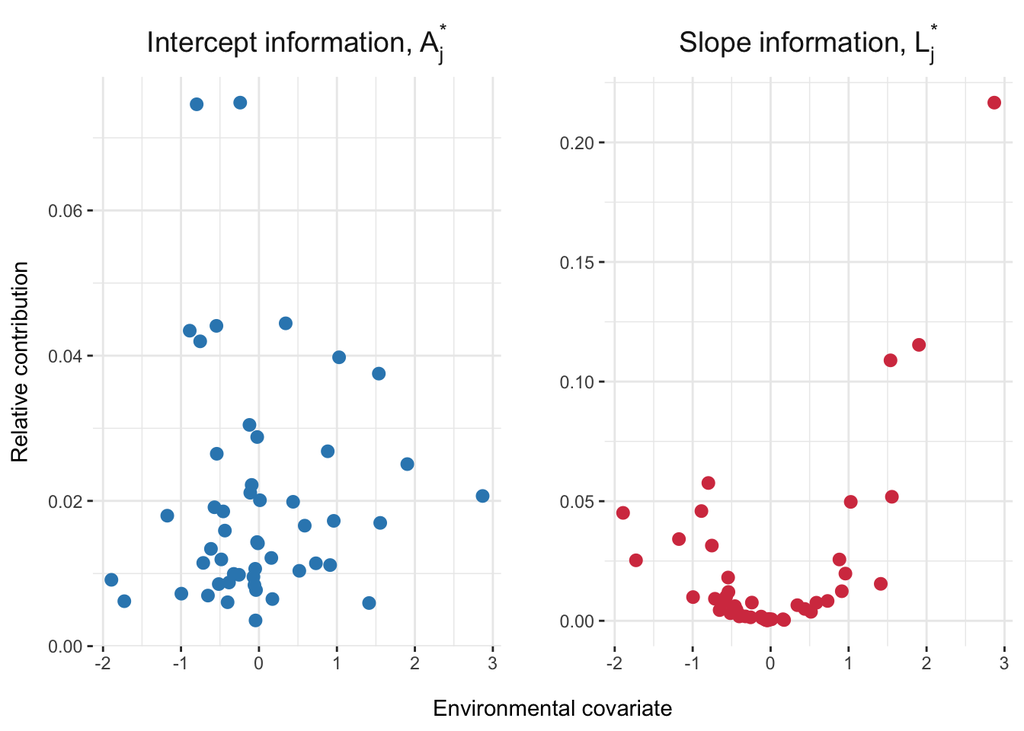

The relative contribution of individual environments differed between estimation of the random-regression intercept and slope. Intercept information, $A_j^*$, was concentrated in environments with greater effective information, whereas slope information, $L_j^*$, additionally reflected the position of each environment along the environmental covariate. Consequently, environments at more extreme covariate values tended to contribute disproportionately to slope estimation, although the realised contribution was modified by heterogeneity in replication, residual variance and environment-specific genetic variance.

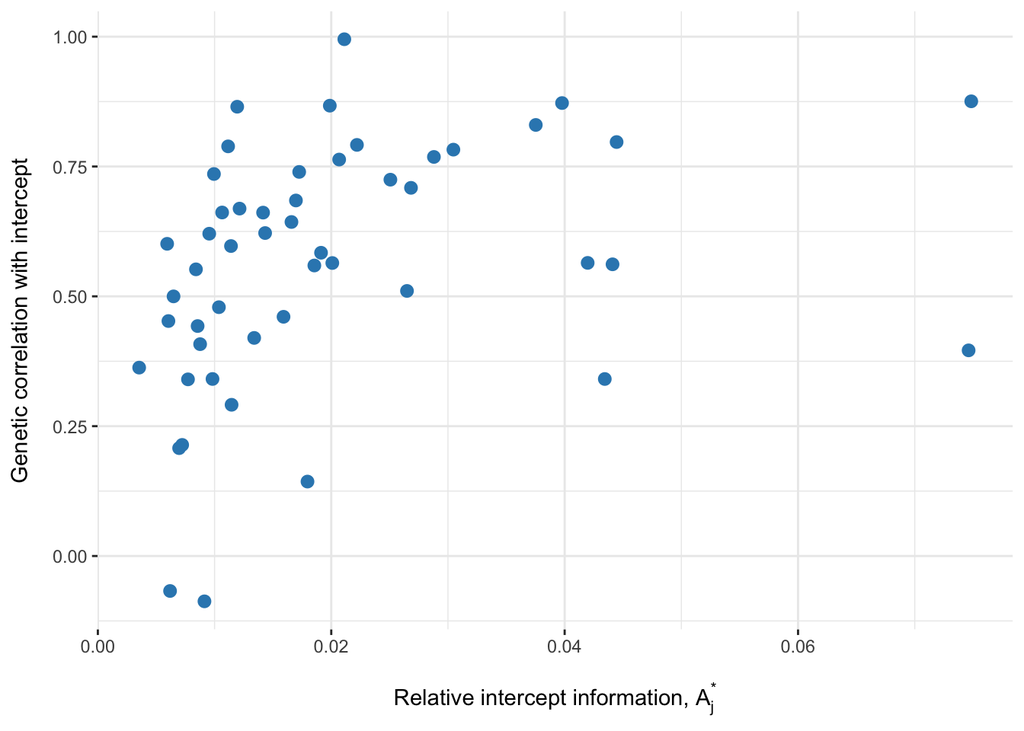

The relationship between relative intercept information, $A_j^*$, and genetic correlation with the intercept showed that environments contributing strongly to estimation of the intercept were not necessarily those most genetically representative of overall genotype performance. The amount of information supplied by an environment is therefore distinct from its genetic similarity to the intercept, with the former determined by the effective precision of the trial data and the latter by the fitted genetic covariance structure across the environmental gradient.

## 5.4 Reliability of predicted intercepts and slopes

```r
# -------------------------------------------------------------------------
# Reliability of predicted intercepts and slopes
# -------------------------------------------------------------------------

# Predict the random-regression genetic component at s = -1, 0, 1
pred_rr <- predict(M_F, classify = "e.cov:geno",
                   levels = list(e.cov = c(-1,0,1)),
                   only = c("geno", "e.cov:geno"),
                   vcov = T,
                   pworkspace = 6e8, maxit = 1)
```

```
## ASReml Version 4.2 15/09/2026 10:03:59
##           LogLik        Sigma2     DF     wall
##  1     -9645.613           1.0   7450   10:04:05
```

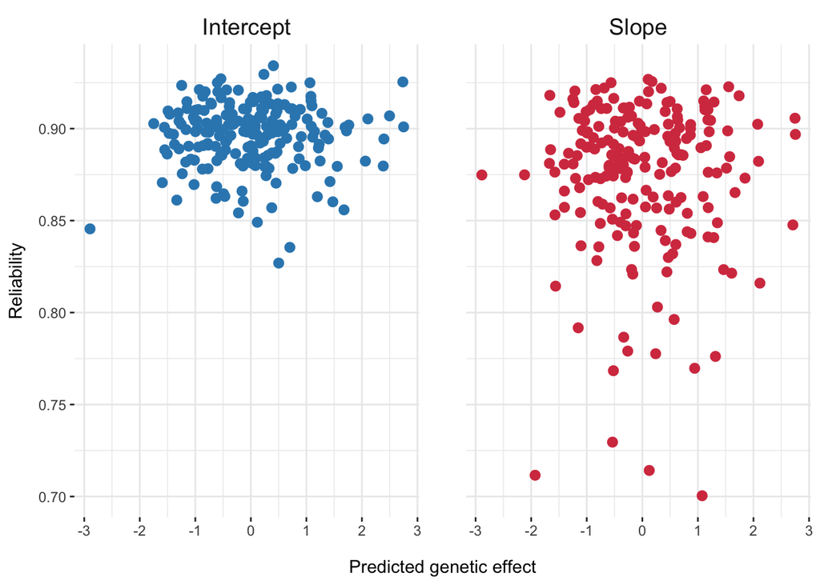

```r
u_0_tilde <- M_F$coefficients$random[grep("^geno", rownames(M_F$coefficients$random)),]
u_1_tilde <- M_F$coefficients$random[grep("e.cov", rownames(M_F$coefficients$random)),]
# plot(pred_rr$pvals$predicted.value[pred_rr$pvals$e.cov==0], u_0_tilde); abline(a=0, b=1) # check
# plot(pred_rr$pvals$predicted.value[pred_rr$pvals$e.cov==1] -
#      pred_rr$pvals$predicted.value[pred_rr$pvals$e.cov==0], u_1_tilde); abline(a=0, b=1) # check
# plot((pred_rr$pvals$predicted.value[pred_rr$pvals$e.cov==1] -
#      pred_rr$pvals$predicted.value[pred_rr$pvals$e.cov==-1])/2, u_1_tilde); abline(a=0, b=1) #

pv <- pred_rr$pvals
P <- as.matrix(pred_rr$vcov)

# Indices for each genotype at s = -1, 0, 1
idx <- lapply(geno_names, function(g)
  match(paste(g, c(-1, 0, 1)),
        paste(pv$geno, pv$e.cov))
)
names(idx) <- geno_names

# Predicted intercepts, slopes and their PEVs
rr_info <- data.frame(
  geno = geno_names,
  intercept = NA_real_,
  slope = NA_real_,
  PEV_0 = NA_real_,
  PEV_1 = NA_real_
)

for(i in seq_len(ngenos)) {

  ii <- idx[[i]]
  p <- pv$predicted.value[ii]
  Pi <- P[ii, ii]

  # u0 = g(0); u1 = [g(1) - g(-1)] / 2
  rr_info$intercept[i] <- p[2]
  rr_info$slope[i] <- (p[3] - p[1]) / 2

  rr_info$PEV_0[i] <- Pi[2, 2]
  rr_info$PEV_1[i] <- (
    Pi[1, 1] + Pi[3, 3] - 2 * Pi[1, 3]
  ) / 4
}

# Genotype-level reliability
Gii <- diag(G)[rr_info$geno]
rr_info$rel_0 <- 1 - rr_info$PEV_0 / (var_0_hat * Gii)
rr_info$rel_1 <- 1 - rr_info$PEV_1 / (var_1_hat * Gii)

# Effective error variance for each genotype
rr_info$efferr_0 <- rr_info$PEV_0 / rr_info$rel_0
rr_info$efferr_1 <- rr_info$PEV_1 / rr_info$rel_1
```

```r
# Population-level reliability
pop_rel_0 <- 1 - mean(rr_info$PEV_0) / mean(var_0_hat * Gii)
pop_rel_1 <- 1 - mean(rr_info$PEV_1) / mean(var_1_hat * Gii)

# Population-level effective error variance
pop_efferr_0 <- mean(rr_info$PEV_0) / pop_rel_0
pop_efferr_1 <- mean(rr_info$PEV_1) / pop_rel_1

# Overall summaries
mean_efferr <- data.frame(
  component = c("Intercept", "Slope"),
  effective_error_variance = c(
    mean(rr_info$efferr_0),
    mean(rr_info$efferr_1)
  ),
  mean_reliability = c(
    mean(rr_info$rel_0),
    mean(rr_info$rel_1)
  ),
    pop_efferr = c(
    pop_efferr_0,
    pop_efferr_1
  ),
    pop_reliability = c(
    pop_rel_0,
    pop_rel_1
  )
)

mean_efferr
```

```
##   component effective_error_variance mean_reliability pop_efferr
## 1 Intercept                0.1161151        0.8962383  0.1156726
## 2     Slope                0.1599044        0.8746701  0.1569843
##   pop_reliability
## 1       0.8963551
## 2       0.8747990
```

## 5.5 Decorrelating the intercepts and slopes

```r
# -------------------------------------------------------------------------
# Decorrelated slopes
# -------------------------------------------------------------------------

beta_hat <- cov_01_hat / var_0_hat
var_1star_hat <- var_1_hat - cov_01_hat^2 / var_0_hat

# Transform environment information to (u0, u1*) basis
Adec_j <- Bdec_j <- Cdec_j <- Ldec_j <- vector("list", nenvs)
names(Adec_j) <- names(Bdec_j) <- names(Cdec_j) <-
  names(Ldec_j) <- env_names

for(e in env_names){

  Adec_j[[e]] <- A_j[[e]] +
    beta_hat * (B_j[[e]] + t(B_j[[e]])) +
    beta_hat^2 * C_j[[e]]

  Bdec_j[[e]] <- B_j[[e]] + beta_hat * C_j[[e]]
  Cdec_j[[e]] <- C_j[[e]]
}

# Total information
Adec <- Reduce("+", Adec_j)
Bdec <- Reduce("+", Bdec_j)
Cdec <- Reduce("+", Cdec_j)

# Conditional information for decorrelated slope
Kdec <- MASS::ginv(Adec) %*% Bdec
I1dec <- Cdec - t(Bdec) %*% MASS::ginv(Adec) %*% Bdec

# Contribution of each environment
for(e in env_names){

  Ldec_j[[e]] <- Cdec_j[[e]] -
    t(Bdec_j[[e]]) %*% Kdec -
    t(Kdec) %*% Bdec_j[[e]] +
    t(Kdec) %*% Adec_j[[e]] %*% Kdec
}

env_info$Ldec_j <- sapply(Ldec_j, function(x) sum(diag(x)))
env_info$Ldecstar_j <- env_info$Ldec_j / sum(env_info$Ldec_j)

# Check
c(sum(env_info$Ldec_j), sum(diag(I1dec)))
```

```
## [1] 937.5944 937.5944
```

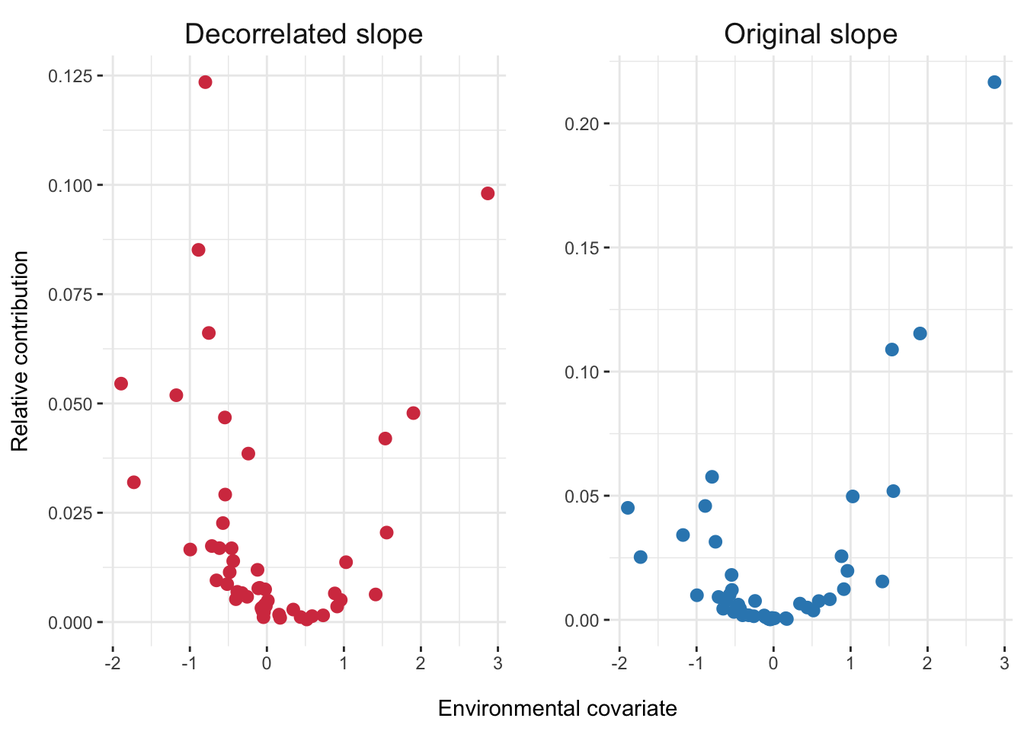

```r
# -------------------------------------------------------------------------
# Reliability of decorrelated slopes
# -------------------------------------------------------------------------

idx_m <- sapply(idx, `[`, 1)
idx_0 <- sapply(idx, `[`, 2)
idx_p <- sapply(idx, `[`, 3)

# Prediction-error covariance matrices
PEV_0_mat <- P[idx_0, idx_0]

PEV_1_mat <- (
  P[idx_p, idx_p] +
  P[idx_m, idx_m] -
  P[idx_p, idx_m] -
  P[idx_m, idx_p]
) / 4

PEC_01_mat <- (
  P[idx_0, idx_p] -
  P[idx_0, idx_m]
) / 2

# Decorrelated predicted slope
rr_info$slope_star <-
  rr_info$slope - beta_hat * rr_info$intercept

# Prediction-error covariance of decorrelated slope
PEV_1star_mat <- PEV_1_mat +
  beta_hat^2 * PEV_0_mat -
  beta_hat * (PEC_01_mat + t(PEC_01_mat))

rr_info$PEV_1star <- diag(PEV_1star_mat)

# Genotype-level reliability
rr_info$rel_1star <- 1 -
  rr_info$PEV_1star / (var_1star_hat * Gii)

# Effective error variance
rr_info$efferr_1star <-
  rr_info$PEV_1star / rr_info$rel_1star
```

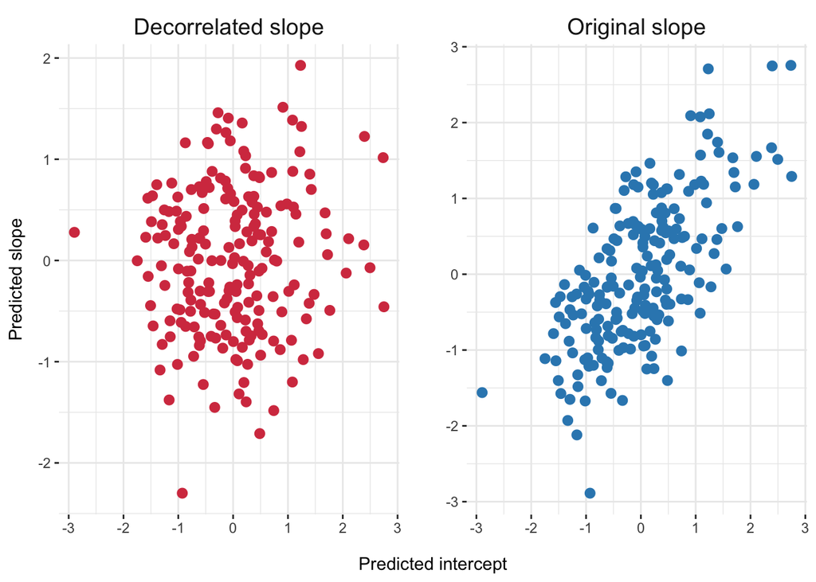

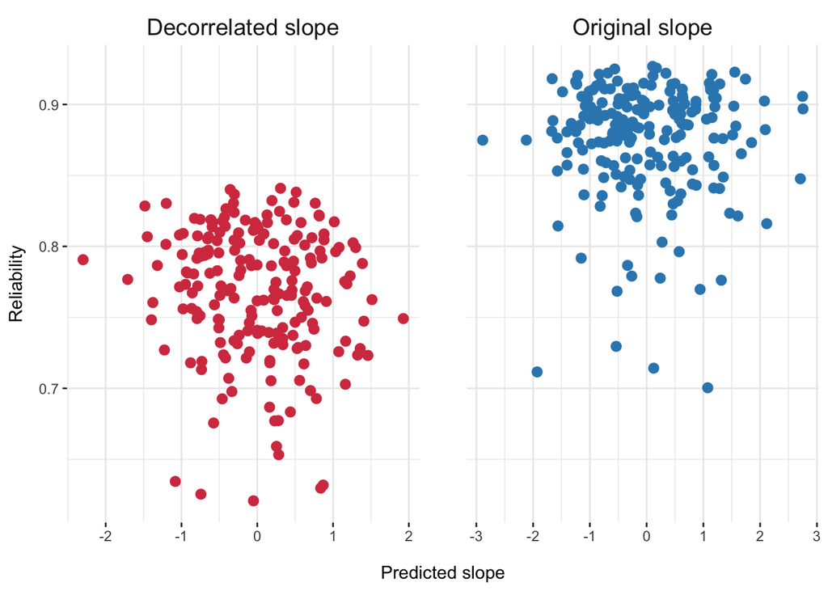

```r
plot_df <- rbind(
  data.frame(
    value = rr_info$slope,
    reliability = rr_info$rel_1,
    component = "Original slope"
  ),
  data.frame(
    value = rr_info$slope_star,
    reliability = rr_info$rel_1star,
    component = "Decorrelated slope"
  )
)

ggplot(plot_df, aes(value, reliability, colour = component)) +
  geom_point(size = 2.5) +
  facet_wrap(~ component, ncol = 2, scales = "free_x") +
  scale_colour_manual(values = c(
    "Original slope" = "#3288BD",
    "Decorrelated slope" = "#D53E4F"
  )) +
  labs(
    x = "Predicted slope",
    y = "Reliability",
    colour = NULL
  ) +
  theme_bw() +
  theme(
    legend.position = "none",
    axis.title.y = element_text(margin = margin(r = 8)),
    axis.title.x = element_text(margin = margin(t = 13)),
    strip.background = element_blank(),
    strip.text = element_text(size = 14),
    panel.spacing = grid::unit(2, "lines"),
    panel.border = element_blank()
  )
```

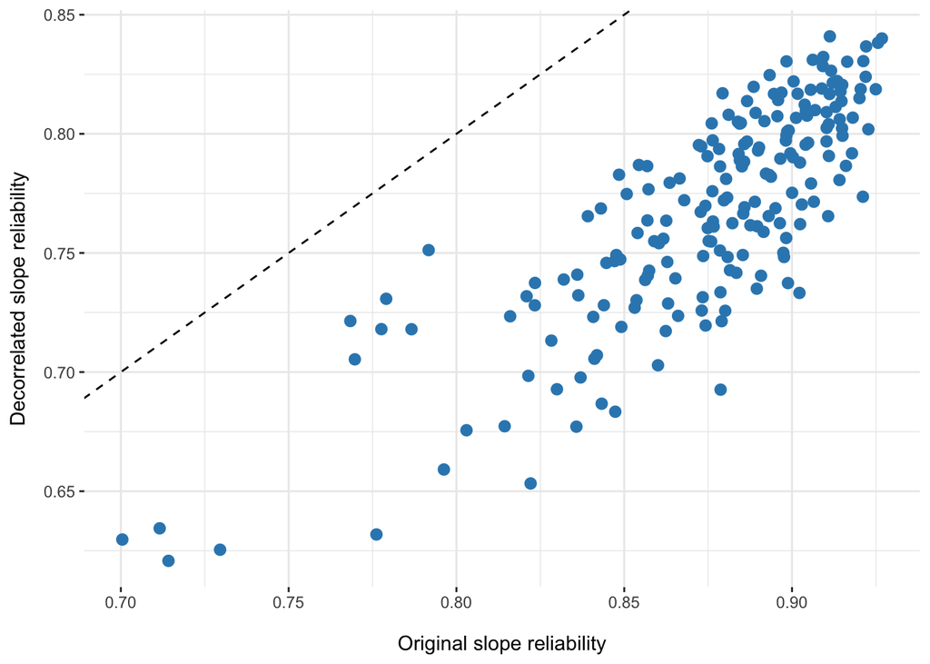

```r
ggplot(rr_info, aes(rel_1, rel_1star)) +
  geom_point(size = 2.5, colour = "#3288BD") +
  geom_abline(intercept = 0, slope = 1, linetype = 2) +
  labs(
    x = "Original slope reliability",
    y = "Decorrelated slope reliability"
  ) +
  theme_bw() +
  theme(
    axis.title.y = element_text(margin = margin(r = 8)),
    axis.title.x = element_text(margin = margin(t = 13)),
    panel.border = element_blank()
  )
```

```r
# Population-level reliability
pop_rel_1star <- 1 - mean(rr_info$PEV_1star) / mean(var_1star_hat * Gii)

# Population-level effective error variance
pop_efferr_1star <- mean(rr_info$PEV_1star) / pop_rel_1star

# Overall summaries
mean_efferr <- data.frame(
  component = c("Decorrelated slope", "Original slope"),
  effective_error_variance = c(
    mean(rr_info$efferr_1star),
    mean(rr_info$efferr_1)
  ),
  mean_reliability = c(
    mean(rr_info$rel_1star),
    mean(rr_info$rel_1)
  ),
    pop_efferr = c(
    pop_efferr_1star,
    pop_efferr_1
  ),
    pop_reliability = c(
    pop_rel_1star,
    pop_rel_1
  )
)
mean_efferr
```

```
##            component effective_error_variance mean_reliability pop_efferr
## 1 Decorrelated slope                0.2131057        0.7675874  0.2097154
## 2     Original slope                0.1599044        0.8746701  0.1569843
##   pop_reliability
## 1       0.7677367
## 2       0.8747990
```

Erbe, Malena, Christian Edel, Reiner Emmerling, and Kay-Uwe Götz. 2022. “Assessing Various Environmental Descriptors with Respect to Genotype x Environment Interaction for Milk Production Traits in Bavarian Fleckvieh Cattle.” *Journal of Animal Breeding and Genetics* 139 (6): 634–53. https://doi.org/10.1111/jbg.12722.

Gorjanc, Gregor, Piter Bijma, and John M. Hickey. 2015. “Reliability of Pedigree-Based and Genomic Evaluations in Selected Populations.” *Genetics Selection Evolution* 47: 65. https://doi.org/10.1186/s12711-015-0145-1.

Henderson, C. R. 1984. *Applications of Linear Models in Animal Breeding*. Guelph, Ontario: University of Guelph.

Martin, Julien G. A., Daniel H. Nussey, Alastair J. Wilson, and Denis Réale. 2011. “Measuring Individual Differences in Reaction Norms in Field and Experimental Studies: A Power Analysis of Random Regression Models.” *Methods in Ecology and Evolution* 2 (4): 362–74. https://doi.org/10.1111/j.2041-210X.2010.00084.x.

Pol, Martijn van de. 2012. “Quantifying Individual Variation in Reaction Norms: How Study Design Affects the Accuracy, Precision and Power of Random Regression Models.” *Methods in Ecology and Evolution* 3 (2): 268–80. https://doi.org/10.1111/j.2041-210X.2011.00160.x.

Self, Steven G., and Kung-Yee Liang. 1987. “Asymptotic Properties of Maximum Likelihood Estimators and Likelihood Ratio Tests Under Nonstandard Conditions.” *Journal of the American Statistical Association* 82 (398): 605–10. https://doi.org/10.1080/01621459.1987.10478472.

Smith, Alison, Brian R. Cullis, and Arthur R. Gilmour. 2001. “The Analysis of Crop Variety Evaluation Data in Australia.” *Australian & New Zealand Journal of Statistics* 43 (2): 129–45. https://doi.org/10.1111/1467-842X.00163.

Stram, Daniel O., and Jae Won Lee. 1994. “Variance Components Testing in the Longitudinal Mixed Effects Model.” *Biometrics* 50 (4): 1171–77.